[figure not shown]

# Analysis of Genre in Anime

Esteban Duran Sampdro

## Introduction

Anime in japan is short for animation feature, so basically over there the word is used to reffer to any animated work, such as a Pixar film or a South Park episode. Conversly the term outside Japan is used to reffer to cartoons from Japan, particularly the ones with the big flashy eyes and extravagant hair styles. This isolation of the term in the"west" has downgraded the word to a genre, a mere format for *children Shows*.

However this scrutiny also points out what it really is, a medium for story telling, that happens to excel at fictional stories. More specifically an expancion to the animation feature medium set, as how the Japanese might see it as animations from home. The reason to call it an expancion, and not a subset (although an expancion it self is a sort of subset) is the variaty of genres in the anime, I mean there are more genres in anime than the traditional 'western' ones.

So from a set that tends to categorice its subsets into genres, then one can't create a subset that contains more genres than the original ones (disregarding combinations of the original ones), yet the desired subset might add to the different possible categories of genres, hense anime expands the animation feature story telling medium.

Before I loose myself in semantics, the point is that anime as an isolated story telling medium, is one that has shown great genre variety growth. The fact that anime shows high amount of surgances of new genres and/or combinations of them, and that it retains the attention of a huge fan community, inside or outside of Japan, is what's captivating from this source.

Moreover in a world more connected than ever, trends and inspirations flow faster and faster. Which means that studying a medium that shows high category variety of artistic expresion, it is worthy of study. As findings may help understand evolution of mediums of fiction, the apperance of anime trends and/or correlations with trends in other sources of fiction.

[MyAnimeList](https://myanimelist.net/about.php) is "the world's largest anime and manga database and community", whose users make list's of anime or manga(Japanese comics), are able to rate the shows, write reviews, and participate community forums. The kaggle [data set](https://www.kaggle.com/azathoth42/myanimelist), by user azathoth42, contains craweled data of MyanimeList, with information about different animes their different metrics (score, genre, popularity, release/broadcasting dates...), users demographics, and users lists (anime, score, status...).

This tutorial seeks to explore and analyze the "growth" of genre in anime over the years, and some of the metrics that may help understand the perception of these genres and different changes.

## Data Loading

To explore, manipulate and analize the data Python 3 with the libraries: [pandas](https://pandas.pydata.org/), [NumPy](http://www.numpy.org/), [Matplotlib](https://matplotlib.org/), [seaborn](https://seaborn.pydata.org), [Graphviz](https://www.graphviz.org/), [IPython](https://ipython.org/) and [scikit-learn](https://scikit-learn.org/stable/).

```python
import pandas as pd
import numpy as np
import matplotlib.pyplot as plt
import seaborn as sns
from sklearn.ensemble import RandomForestClassifier
from sklearn.tree import export_graphviz
from IPython.display import Image
import pydot
import warnings
warnings.filterwarnings('ignore')
```

```python
animedf = pd.read_csv('anime_cleaned.csv')
```

Below we load the cvs(comma sepparated value) files for different animes, and lists of anime per user. Both tables are loaded into a pandas data frame.

```python
animedf = pd.read_csv('anime_cleaned.csv')
anime_listsdf = pd.read_csv('animelists_cleaned.csv')
animedf.head()
```

|  | anime_id | title | title_english | title_japanese | title_synonyms | image_url | type | source | episodes | status | ... | broadcast | related | producer | licensor | studio | genre | opening_theme | ending_theme | duration_min | aired_from_year |
| --- | --- | --- | --- | --- | --- | --- | --- | --- | --- | --- | --- | --- | --- | --- | --- | --- | --- | --- | --- | --- | --- |
| 0 | 11013 | Inu x Boku SS | Inu X Boku Secret Service | 妖狐×僕SS | Youko x Boku SS | https://myanimelist.cdn-dena.com/images/anime/... | TV | Manga | 12 | Finished Airing | ... | Fridays at Unknown | {'Adaptation': [{'mal_id': 17207, 'type': 'man... | Aniplex, Square Enix, Mainichi Broadcasting Sy... | Sentai Filmworks | David Production | Comedy, Supernatural, Romance, Shounen | ['"Nirvana" by MUCC'] | ['#1: "Nirvana" by MUCC (eps 1, 11-12)', '#2: ... | 24.0 | 2012.0 |
| 1 | 2104 | Seto no Hanayome | My Bride is a Mermaid | 瀬戸の花嫁 | The Inland Sea Bride | https://myanimelist.cdn-dena.com/images/anime/... | TV | Manga | 26 | Finished Airing | ... | Unknown | {'Adaptation': [{'mal_id': 759, 'type': 'manga... | TV Tokyo, AIC, Square Enix, Sotsu | Funimation | Gonzo | Comedy, Parody, Romance, School, Shounen | ['"Romantic summer" by SUN&LUNAR'] | ['#1: "Ashita e no Hikari (明日への光)" by Asuka Hi... | 24.0 | 2007.0 |
| 2 | 5262 | Shugo Chara!! Doki | Shugo Chara!! Doki | しゅごキャラ！！どきっ | Shugo Chara Ninenme, Shugo Chara! Second Year | https://myanimelist.cdn-dena.com/images/anime/... | TV | Manga | 51 | Finished Airing | ... | Unknown | {'Adaptation': [{'mal_id': 101, 'type': 'manga... | TV Tokyo, Sotsu | NaN | Satelight | Comedy, Magic, School, Shoujo | ['#1: "Minna no Tamago (みんなのたまご)" by Shugo Cha... | ['#1: "Rottara Rottara (ロッタラ ロッタラ)" by Buono! ... | 24.0 | 2008.0 |
| 3 | 721 | Princess Tutu | Princess Tutu | プリンセスチュチュ | NaN | https://myanimelist.cdn-dena.com/images/anime/... | TV | Original | 38 | Finished Airing | ... | Fridays at Unknown | {'Adaptation': [{'mal_id': 1581, 'type': 'mang... | Memory-Tech, GANSIS, Marvelous AQL | ADV Films | Hal Film Maker | Comedy, Drama, Magic, Romance, Fantasy | ['"Morning Grace" by Ritsuko Okazaki'] | ['"Watashi No Ai Wa Chiisaikeredo" by Ritsuko ... | 16.0 | 2002.0 |
| 4 | 12365 | Bakuman. 3rd Season | Bakuman. | バクマン。 | Bakuman Season 3 | https://myanimelist.cdn-dena.com/images/anime/... | TV | Manga | 25 | Finished Airing | ... | Unknown | {'Adaptation': [{'mal_id': 9711, 'type': 'mang... | NHK, Shueisha | NaN | J.C.Staff | Comedy, Drama, Romance, Shounen | ['#1: "Moshimo no Hanashi (もしもの話)" by nano.RIP... | ['#1: "Pride on Everyday" by Sphere (eps 1-13)... | 24.0 | 2012.0 |

5 rows × 33 columns

Above there's the first five values of the anime table, this tables contains abobut 6600 different anime entries. There are 33 different atributes per entry, some of which will be dropped and others be explored in more detail later on. So descriptions of these values as te cleaning of data goes on.

```python
anime_listsdf.head()
```

|  | username | anime_id | my_watched_episodes | my_start_date | my_finish_date | my_score | my_status | my_rewatching | my_rewatching_ep | my_last_updated | my_tags |
| --- | --- | --- | --- | --- | --- | --- | --- | --- | --- | --- | --- |
| 0 | karthiga | 21 | 586 | 0000-00-00 | 0000-00-00 | 9 | 1 | NaN | 0 | 2013-03-03 10:52:53 | NaN |
| 1 | karthiga | 59 | 26 | 0000-00-00 | 0000-00-00 | 7 | 2 | NaN | 0 | 2013-03-10 13:54:51 | NaN |
| 2 | karthiga | 74 | 26 | 0000-00-00 | 0000-00-00 | 7 | 2 | NaN | 0 | 2013-04-27 16:43:35 | NaN |
| 3 | karthiga | 120 | 26 | 0000-00-00 | 0000-00-00 | 7 | 2 | NaN | 0 | 2013-03-03 10:53:57 | NaN |
| 4 | karthiga | 178 | 26 | 0000-00-00 | 0000-00-00 | 7 | 2 | 0.0 | 0 | 2013-03-27 15:59:13 | NaN |

Now above this there's the first five values of the user list table. Each row sould be distinguished by its usernmae and anime_id values combination, that indicates that an anime in a user's list. There are 31 million different entries. The other attributes will be detailed as the tabled is cleaned.

[figure not shown]

## Data Washing

We will brush up the data in the anime table first.

We can remove several columns from the table due to redundancy or uselessness of the data in the context of analysing genre.

- title_english, title_japanese, title_synonyms and background may be removed as the title column is enough string representations of the anime.
- airing, aired_string, aired, premiered, and broadcast since air_from_year is enough information about the temporal origin of the show.
- producer and licensor, may be removed as studio provides sufficient information regarding the make of the anime. And since studio variable probably have higher impact on genre than the producer or licensor. As one may consider studio the artit's house, wheras the others more of the money/resources houses.
- opening_theme and ending theme may be removed, as those are simply the intro and outro song names, with image_url. As these columns bear no useful relevance to this analisis.
- finnally related is removed as each value has the form of a data dictionary, that tends to point to a manga_id value from MyAnimeList, or an anime_id, and since the manga data is not available, this column has no usefulness for this tutotial.

The source atribute, describes the inspiration the story and/or style of the anime, such as a book or game. Looking at the possible sources categories, using the unique function on the 'source' column of the anime dataframe, makes me wish there were more detail on the 'Game' and 'Other' lables. As Japan has a history of producing shows in order to promote material from other products in japan, ie card games, toys, video games. Hence the desire of the divition of games into video and non video games, and if possible the divition of other into toys, food or candy, all of which might show more understanding on the apperance of new genres in anime (Sorry for the impertinence MAL, you're an awesome site). Also there are few sources that are too similar, if not a subset format, of the manga source. So those sources may be repleaced simply by manga. Furthermore the Visual novel, novel and light novel source shouldn't be considered as a single source since they are truly different from one another; one refers to novels in prints, novel; other to novels with pictures, light novel; and the other one to novel told with pictures in a video game, visual novel. They might still sound similar but they are distinguished enough to have different influence in genre.

From the type column the rows with the lable music may be removed as such format is more related to the music medium vs the story telling one. I don't mean to say that music can't tell a story, just that it's not it's forte. Also the type OVA stands for original video anime, and ONA original net animeation, basically animes that wer not released in tv, movie, or special format, but where released inpendently online or in tape, just to provide a description of these.

From the different durations of anime one might notice some have lenght under a minute, which reading around those animes make reference to sub/hidden stories within other animes, that is just too specific and there is no need to include those in the analisis. So they get removed by escluding rows that have the string "sec. " which is unique for *animes* under a minute.

Also removing the animes that have status not yet aired, since some of the metrics wouldn't bare a relistic or stable value, such as a score or popularity.

From the genre column, the animes that have no genre value are removed since this tutorial has focuse genre, furthermore there are only 2 animes that lack genre in the data.

Also since years are integer values, changing the vlaue of aired_from_year to an int might be usful, or more clean.

All of this data cleaning is done below. And the data frame after brushing up is shown below.

```python
#removal of columns
animedf.drop(['title_english', 'title_japanese', 'title_synonyms',
              'image_url','airing', 'aired_string', 'aired', 'background',
              'premiered', 'broadcast', 'related', 'producer', 'licensor',
              'opening_theme', 'ending_theme'], axis=1, inplace=True)

#replacing sources similar to manga, with manga
animedf['source'] = animedf['source'].replace(['4-koma manga', 'Web manga', 'Digital manga'], 'Manga')

#removing lines with type music
animedf = animedf[animedf['type'] != 'Music']

#removing animes with duration under a minute
animedf = animedf[~animedf['duration'].str.contains("sec.")]

#removing animes that haven't aired
animedf = animedf[animedf['status'] != 'Not yet aired']

#removing animes without genre value
animedf = animedf[pd.notnull(animedf['genre'])]

#chageing the data typr of aired_from_year from double to int
animedf['aired_from_year']=animedf['aired_from_year'].astype(int)

animedf = animedf.reset_index(drop=True)
animedf
```

|  | anime_id | title | type | source | episodes | status | duration | rating | score | scored_by | rank | popularity | members | favorites | studio | genre | duration_min | aired_from_year |
| --- | --- | --- | --- | --- | --- | --- | --- | --- | --- | --- | --- | --- | --- | --- | --- | --- | --- | --- |
| 0 | 11013 | Inu x Boku SS | TV | Manga | 12 | Finished Airing | 24 min. per ep. | PG-13 - Teens 13 or older | 7.63 | 139250 | 1274.0 | 231 | 283882 | 2809 | David Production | Comedy, Supernatural, Romance, Shounen | 24.0 | 2012 |
| 1 | 2104 | Seto no Hanayome | TV | Manga | 26 | Finished Airing | 24 min. per ep. | PG-13 - Teens 13 or older | 7.89 | 91206 | 727.0 | 366 | 204003 | 2579 | Gonzo | Comedy, Parody, Romance, School, Shounen | 24.0 | 2007 |
| 2 | 5262 | Shugo Chara!! Doki | TV | Manga | 51 | Finished Airing | 24 min. per ep. | PG - Children | 7.55 | 37129 | 1508.0 | 1173 | 70127 | 802 | Satelight | Comedy, Magic, School, Shoujo | 24.0 | 2008 |
| 3 | 721 | Princess Tutu | TV | Original | 38 | Finished Airing | 16 min. per ep. | PG-13 - Teens 13 or older | 8.21 | 36501 | 307.0 | 916 | 93312 | 3344 | Hal Film Maker | Comedy, Drama, Magic, Romance, Fantasy | 16.0 | 2002 |
| 4 | 12365 | Bakuman. 3rd Season | TV | Manga | 25 | Finished Airing | 24 min. per ep. | PG-13 - Teens 13 or older | 8.67 | 107767 | 50.0 | 426 | 182765 | 2082 | J.C.Staff | Comedy, Drama, Romance, Shounen | 24.0 | 2012 |
| 5 | 6586 | Yume-iro Pâtissière | TV | Manga | 50 | Finished Airing | 24 min. per ep. | G - All Ages | 8.03 | 21618 | 526.0 | 1630 | 45625 | 826 | Studio Pierrot, Studio Hibari | Kids, School, Shoujo | 24.0 | 2009 |
| 6 | 178 | Ultra Maniac | TV | Manga | 26 | Finished Airing | 24 min. per ep. | G - All Ages | 7.26 | 9663 | 2594.0 | 2490 | 22778 | 122 | Production Reed | Magic, Comedy, Romance, School, Shoujo | 24.0 | 2003 |
| 7 | 2787 | Shakugan no Shana II (Second) | TV | Light novel | 24 | Finished Airing | 24 min. per ep. | PG-13 - Teens 13 or older | 7.72 | 126085 | 1066.0 | 332 | 220591 | 1075 | J.C.Staff | Action, Drama, Fantasy, Romance, School, Super... | 24.0 | 2007 |
| 8 | 4477 | Nodame Cantabile: Paris-hen | TV | Manga | 11 | Finished Airing | 23 min. per ep. | PG-13 - Teens 13 or older | 8.24 | 53908 | 281.0 | 988 | 85660 | 282 | J.C.Staff | Music, Slice of Life, Comedy, Romance, Josei | 23.0 | 2008 |
| 9 | 853 | Ouran Koukou Host Club | TV | Manga | 26 | Finished Airing | 23 min. per ep. | PG-13 - Teens 13 or older | 8.34 | 335137 | 205.0 | 69 | 538843 | 24072 | Bones | Comedy, Harem, Romance, School, Shoujo | 23.0 | 2006 |
| 10 | 4814 | Junjou Romantica 2 | TV | Manga | 12 | Finished Airing | 24 min. per ep. | PG-13 - Teens 13 or older | 8.15 | 66565 | 374.0 | 799 | 108186 | 1123 | Studio Deen | Comedy, Drama, Romance, Shounen Ai | 24.0 | 2008 |
| 11 | 7054 | Kaichou wa Maid-sama! | TV | Manga | 26 | Finished Airing | 24 min. per ep. | PG-13 - Teens 13 or older | 8.20 | 315130 | 314.0 | 71 | 531292 | 14436 | J.C.Staff | Comedy, Romance, School, Shoujo | 24.0 | 2010 |
| 12 | 11123 | Sekaiichi Hatsukoi 2 | TV | Manga | 12 | Finished Airing | 24 min. per ep. | PG-13 - Teens 13 or older | 8.23 | 53285 | 288.0 | 945 | 89543 | 726 | Studio Deen | Comedy, Drama, Romance, Shounen Ai | 24.0 | 2011 |
| 13 | 14227 | Tonari no Kaibutsu-kun | TV | Manga | 13 | Finished Airing | 24 min. per ep. | PG-13 - Teens 13 or older | 7.71 | 281448 | 1093.0 | 88 | 482105 | 4064 | Brain&#039;s Base | Slice of Life, Comedy, Romance, School, Shoujo | 24.0 | 2012 |
| 14 | 269 | Bleach | TV | Manga | 366 | Finished Airing | 24 min. per ep. | PG-13 - Teens 13 or older | 7.90 | 433097 | 693.0 | 18 | 819284 | 40718 | Studio Pierrot | Action, Adventure, Comedy, Super Power, Supern... | 24.0 | 2004 |
| 15 | 59 | Chobits | TV | Manga | 26 | Finished Airing | 24 min. per ep. | PG-13 - Teens 13 or older | 7.53 | 175388 | 1546.0 | 188 | 317641 | 3271 | Madhouse | Sci-Fi, Comedy, Drama, Romance, Ecchi, Seinen | 24.0 | 2002 |
| 16 | 6045 | Kimi ni Todoke | TV | Manga | 25 | Finished Airing | 22 min. per ep. | PG-13 - Teens 13 or older | 8.13 | 212710 | 400.0 | 111 | 417136 | 8041 | Production I.G | Slice of Life, Drama, Romance, School, Shoujo | 22.0 | 2009 |
| 17 | 1735 | Naruto: Shippuuden | TV | Manga | 500 | Finished Airing | 23 min. per ep. | PG-13 - Teens 13 or older | 8.18 | 385179 | 337.0 | 20 | 794112 | 42846 | Studio Pierrot | Action, Adventure, Comedy, Super Power, Martia... | 23.0 | 2007 |
| 18 | 210 | Ranma ½ | TV | Manga | 161 | Finished Airing | 24 min. per ep. | R+ - Mild Nudity | 7.85 | 59911 | 802.0 | 623 | 134537 | 2742 | Studio Deen | Slice of Life, Comedy, Martial Arts, Fantasy | 24.0 | 1989 |
| 19 | 4224 | Toradora! | TV | Light novel | 25 | Finished Airing | 24 min. per ep. | PG-13 - Teens 13 or older | 8.39 | 557898 | 174.0 | 13 | 910373 | 35322 | J.C.Staff | Slice of Life, Comedy, Romance, School | 24.0 | 2008 |
| 20 | 10030 | Bakuman. 2nd Season | TV | Manga | 25 | Finished Airing | 24 min. per ep. | PG-13 - Teens 13 or older | 8.49 | 122090 | 108.0 | 374 | 201720 | 1023 | J.C.Staff | Comedy, Drama, Romance, Shounen | 24.0 | 2011 |
| 21 | 74 | Gakuen Alice | TV | Manga | 26 | Finished Airing | 25 min. per ep. | G - All Ages | 7.77 | 33244 | 941.0 | 1291 | 62951 | 1403 | Group TAC | Comedy, School, Shoujo, Super Power | 25.0 | 2004 |
| 22 | 4722 | Skip Beat! | TV | Manga | 25 | Finished Airing | 24 min. per ep. | PG-13 - Teens 13 or older | 8.24 | 90699 | 282.0 | 488 | 164738 | 4668 | Hal Film Maker | Comedy, Drama, Romance, Shoujo | 24.0 | 2008 |
| 23 | 14397 | Chihayafuru 2 | TV | Manga | 25 | Finished Airing | 22 min. per ep. | PG-13 - Teens 13 or older | 8.47 | 62720 | 116.0 | 757 | 114340 | 1116 | Madhouse | Drama, Game, Josei, School, Slice of Life, Sports | 22.0 | 2013 |
| 24 | 1557 | Shounen Onmyouji | TV | Light novel | 26 | Finished Airing | 23 min. per ep. | PG-13 - Teens 13 or older | 7.68 | 14619 | 1158.0 | 1793 | 39422 | 274 | Studio Deen | Action, Magic, Fantasy, Supernatural, Demons, ... | 23.0 | 2006 |
| 25 | 10800 | Chihayafuru | TV | Manga | 25 | Finished Airing | 22 min. per ep. | PG-13 - Teens 13 or older | 8.29 | 89081 | 246.0 | 348 | 213902 | 4524 | Madhouse | Drama, Game, Josei, School, Slice of Life, Sports | 22.0 | 2011 |
| 26 | 3731 | Itazura na Kiss | TV | Manga | 25 | Finished Airing | 24 min. per ep. | PG-13 - Teens 13 or older | 7.70 | 91187 | 1108.0 | 473 | 170224 | 2632 | TMS Entertainment | Comedy, Romance, Shoujo | 24.0 | 2008 |
| 27 | 9513 | Beelzebub | TV | Manga | 60 | Finished Airing | 24 min. per ep. | PG-13 - Teens 13 or older | 8.02 | 136105 | 528.0 | 208 | 302082 | 3785 | Pierrot Plus | Action, Comedy, Demons, Supernatural, School, ... | 24.0 | 2011 |
| 28 | 5835 | Hanasakeru Seishounen | TV | Manga | 39 | Finished Airing | 24 min. per ep. | PG-13 - Teens 13 or older | 7.87 | 16772 | 753.0 | 1654 | 44633 | 500 | Studio Pierrot | Drama, Romance, Shoujo | 24.0 | 2009 |
| 29 | 9863 | SKET Dance | TV | Manga | 77 | Finished Airing | 24 min. per ep. | PG-13 - Teens 13 or older | 8.33 | 44132 | 213.0 | 646 | 130264 | 2474 | Tatsunoko Production | Comedy, School, Shounen | 24.0 | 2011 |
| ... | ... | ... | ... | ... | ... | ... | ... | ... | ... | ... | ... | ... | ... | ... | ... | ... | ... | ... |
| 6444 | 37133 | Tenkousei wa Kounin Kaikeishi! | OVA | Original | 1 | Finished Airing | 17 min. | PG-13 - Teens 13 or older | 4.56 | 9 | 12395.0 | 13845 | 60 | 0 | TYO Animations | Slice of Life, School | 17.0 | 2013 |
| 6445 | 35140 | Heisei Matsue Kaidan: Ayashi | ONA | Original | 0 | Currently Airing | 9 min. | G - All Ages | 4.47 | 17 | 10378.0 | 12294 | 132 | 0 | DLE | Comedy, Historical, Parody, Horror, Supernatural | 9.0 | 2017 |
| 6446 | 23003 | Tanoshii Bunmeishi: Tetsu Monogatari | Movie | Original | 1 | Finished Airing | 25 min. | G - All Ages | 5.71 | 7 | 12364.0 | 12415 | 127 | 0 | Toei Animation | Historical, Slice of Life | 25.0 | 1962 |
| 6447 | 37620 | CMFU Xueyuan: Shenshi Ji Jijian | ONA | Novel | 24 | Finished Airing | 12 min. per ep. | PG-13 - Teens 13 or older | 4.00 | 2 | 9903.0 | 12909 | 104 | 0 | Shanghai Foch Film Culture Investment | Sports, Romance, School | 12.0 | 2017 |
| 6448 | 35593 | Meiken Lassie: Yume ni Mukatte Hashire! | Special | Novel | 1 | Finished Airing | 23 min. | G - All Ages | 6.50 | 4 | 11218.0 | 13864 | 57 | 0 | Nippon Animation | Adventure, Kids, Slice of Life | 23.0 | 2002 |
| 6449 | 37814 | Inazuma Eleven Reloaded: Reformation of Soccer | Special | Game | 1 | Finished Airing | 24 min. | G - All Ages | 0.00 | 0 | 10587.0 | 14429 | 610 | 0 | OLM | Sports | 24.0 | 2018 |
| 6450 | 35817 | Curry no Kuni no Coburoux | TV | Original | 13 | Finished Airing | 4 min. per ep. | G - All Ages | 6.57 | 7 | 9930.0 | 13753 | 63 | 0 | Artland | Comedy | 4.0 | 2004 |
| 6451 | 36582 | Life: Jinsei no Taisetsu na Toki ni... | ONA | Original | 1 | Finished Airing | 3 min. | G - All Ages | 4.91 | 23 | 11075.0 | 13861 | 58 | 0 | dwarf | Slice of Life | 3.0 | 2013 |
| 6452 | 37860 | Free!: Take Your Marks: Character Butai Aisatsu | Movie | Original | 4 | Finished Airing | 6 min. per ep. | PG-13 - Teens 13 or older | 0.00 | 0 | 10120.0 | 14427 | 364 | 0 | Kyoto Animation | Comedy | 6.0 | 2017 |
| 6453 | 34490 | Sushi Azarashi | TV | Picture book | 30 | Finished Airing | Unknown | PG - Children | 4.17 | 6 | 12305.0 | 13463 | 77 | 0 | M.S.C | Comedy | 0.0 | 2001 |
| 6454 | 35142 | Yoshida no Matsue Beauty Daisakusen | ONA | Original | 0 | Currently Airing | 5 min. | G - All Ages | 6.37 | 19 | 12775.0 | 12395 | 128 | 0 | DLE | Comedy, Parody | 5.0 | 2017 |
| 6455 | 37802 | Ongeki | ONA | Game | 0 | Currently Airing | 1 min. | G - All Ages | 4.80 | 5 | 11620.0 | 14263 | 30 | 0 | J.C.Staff | Slice of Life | 1.0 | 2017 |
| 6456 | 37859 | Free! Movie 2: Timeless Medley - Yakusoku: Cha... | Movie | Original | 4 | Finished Airing | 5 min. per ep. | PG-13 - Teens 13 or older | 0.00 | 0 | 10119.0 | 14426 | 261 | 0 | Kyoto Animation | Comedy | 5.0 | 2017 |
| 6457 | 23245 | Go Go Toraemon | OVA | Manga | 1 | Finished Airing | 30 min. | None | 5.14 | 14 | 10236.0 | 13027 | 99 | 0 | Studio Pierrot | Comedy, Sports | 30.0 | 1986 |
| 6458 | 34845 | Ponkotsu Quest Specials | ONA | Original | 0 | Currently Airing | 2 min. | G - All Ages | 5.50 | 6 | 11794.0 | 12983 | 100 | 0 | Pie in The Sky | Comedy, Parody, Fantasy | 2.0 | 2014 |
| 6459 | 37619 | CMFU Xueyuan: Wangzi Peng Peng Qiu | ONA | Novel | 24 | Finished Airing | 11 min. per ep. | PG-13 - Teens 13 or older | 6.75 | 8 | 9904.0 | 13444 | 79 | 0 | Shanghai Foch Film Culture Investment | Romance, School, Sports | 11.0 | 2016 |
| 6460 | 37858 | Free! Movie 1: Timeless Medley - Kizuna: Chara... | Movie | Original | 4 | Finished Airing | 4 min. per ep. | PG-13 - Teens 13 or older | 0.00 | 0 | 10118.0 | 14425 | 298 | 0 | Kyoto Animation | Comedy | 4.0 | 2017 |
| 6461 | 37895 | Ling Yu 5th Season | ONA | Novel | 12 | Finished Airing | 13 min. per ep. | PG-13 - Teens 13 or older | 7.50 | 10 | 11127.0 | 13848 | 71 | 0 | Haoliners Animation League | Fantasy | 13.0 | 2017 |
| 6462 | 37888 | Tian Yu | ONA | Game | 13 | Finished Airing | 13 min. per ep. | PG-13 - Teens 13 or older | 6.00 | 4 | 12485.0 | 14211 | 41 | 0 | Sparkly Key Animation Studio | Action, Adventure, Demons, Fantasy, Magic | 13.0 | 2017 |
| 6463 | 37667 | Heisei Matsue Kaidan | ONA | Original | 7 | Finished Airing | 4 min. per ep. | G - All Ages | 4.69 | 13 | 10421.0 | 14003 | 54 | 0 | DLE | Horror, Parody, Supernatural | 4.0 | 2015 |
| 6464 | 37090 | Hitori no Shita: The Outcast Recap | Special | Manga | 1 | Finished Airing | 24 min. | R - 17+ (violence & profanity) | 6.04 | 181 | 7261.0 | 8378 | 1013 | 2 | Haoliners Animation League | Action, Super Power, Supernatural | 24.0 | 2018 |
| 6465 | 37493 | Watashitachi no Mirai | OVA | Original | 1 | Finished Airing | Unknown | G - All Ages | 4.00 | 1 | 12704.0 | 14466 | 19 | 0 | Nippon Animation | Kids | 0.0 | 2018 |
| 6466 | 37896 | Ling Yu 6th Season | ONA | Novel | 0 | Currently Airing | 12 min. | PG-13 - Teens 13 or older | 7.80 | 5 | 11128.0 | 13725 | 71 | 0 | Shanghai Foch Film Culture Investment | Fantasy | 12.0 | 2018 |
| 6467 | 37494 | Chikyuu to no Yakusoku | OVA | Original | 1 | Finished Airing | Unknown | G - All Ages | 0.00 | 0 | 9913.0 | 14468 | 18 | 0 | Tezuka Productions | Kids | 0.0 | 2018 |
| 6468 | 37894 | Ling Yu 4th Season | ONA | Novel | 12 | Finished Airing | 13 min. per ep. | PG-13 - Teens 13 or older | 7.53 | 17 | 11126.0 | 12779 | 126 | 0 | Haoliners Animation League | Fantasy | 13.0 | 2016 |
| 6469 | 37405 | Dokidoki Little Ooyasan | OVA | Other | 0 | Currently Airing | 30 min. | Rx - Hentai | 9.52 | 33 | NaN | 10273 | 357 | 21 | Collaboration Works | Hentai | 30.0 | 2018 |
| 6470 | 37886 | Wo Shi Jiang Xiaobai (2018) | ONA | Original | 1 | Finished Airing | Unknown | PG-13 - Teens 13 or older | 0.00 | 0 | 12719.0 | 10168 | 384 | 1 | 2:10 Animation | Slice of Life, Drama, Romance | 0.0 | 2018 |
| 6471 | 37255 | Genki Genki Non-tan: Obake Mura Meiro | OVA | Original | 1 | Finished Airing | 35 min. | G - All Ages | 4.20 | 5 | 10253.0 | 14257 | 37 | 0 | Polygon Pictures | Music, Kids | 35.0 | 2015 |
| 6472 | 35229 | Mr. Men Little Miss | ONA | Picture book | 0 | Currently Airing | 2 min. | G - All Ages | 4.57 | 7 | 11396.0 | 14066 | 49 | 1 | Sanrio | Kids | 2.0 | 2013 |
| 6473 | 36315 | Mushi Mushi Mura no Nakama-tachi: Minna Ii Tok... | OVA | Original | 1 | Finished Airing | 13 min. | G - All Ages | 7.00 | 4 | 11396.0 | 14191 | 40 | 0 | Toei Animation | Kids | 13.0 | 2017 |

6474 rows × 18 columns

The genre atribute that has the form of a list of genres per anime requires special attention. So in order to unfold this sublists within each anime 43 different columns, one per genre, would be added to the data frame; if an anime has that genre in it, it will contain a 1, 0 otherwise.

Below is the code to add the columns in the data frame. With code to collect a list of each anime genres as a list, which will be useful later on.

```python
#list of the 43 differnt genres in anime
genres = ['Action', 'Adventure', 'Cars', 'Comedy', 'Dementia', 'Demons',
          'Drama', 'Ecchi', 'Fantasy', 'Game', 'Harem', 'Hentai', 'Historical',
          'Horror', 'Josei', 'Kids', 'Magic', 'Martial Arts', 'Mecha',
          'Military', 'Music', 'Mystery', 'Parody', 'Police', 'Psychological',
          'Romance', 'Samurai', 'School', 'Sci-Fi', 'Seinen', 'Shoujo',
          'Shoujo Ai', 'Shounen', 'Shounen Ai', 'Slice of Life', 'Space',
          'Sports', 'Super Power', 'Supernatural', 'Thriller', 'Vampire',
          'Yaoi', 'Yuri']

#adding boolean columns per genre in each anime
for g in genres:
    animedf[g] = animedf['genre'].str.contains(g)

#convering the specific genres boolean columns into binary ones
for g in genres:
    animedf[g] = animedf[g].astype(int)

#collection of the list of genres in each anime
anime_genres_set = list(map(str, (animedf['genre'])))
```

Now we clean the users list data.

Some columns from this table may be removed as well

- my_start_date, my_finish_date, are too user specific, also the lack of values in some columns such as finish date would make it dificult to find a data relevant for genre such as mean time lapse speed to complete a specific genre show.
- my_rewatching_ep is too redundant on the my_rewatching, it is enough to now if a user deems the anime valuable enough to rewatch, but not the number of episodes. also there was some user that claimed it had rewatched a lewd anime for more than thousands of years. So getting rid of internet troll data is good too.
- my_watched_episodes is not relevant for this genre analysis as simply knowing that the user was interested in an anime of zed genre, regardles of the amount of episodes watched will suffice.
- my_last_update and my_tags are irrelevant for this analisis, as the last time the show was updated by user dosnt matter and the tags vary too much, often unique for a show and/or user.

The my_rewatching column contain either 1s, 0s or null values, so filling the null values with zeros would tidy this pice of data.

Some username values are null, so this would be dificult to define the null user a single one, morover when there could be overlap of rows with nullfor user and same anime_id. So removing the rows for the null users.

The status atributes possible values are described as follow: 1, watching; 2, completed; 3, on hold; 4, dropped; 6, plan to watch. But within the possible values found there are also 5, 55, 0 and 33. As 5, 55 and 0 are not a status with any meanig they are removed, and the 33 varaible will be interpreted as a typo and replaced with a 3.

Below is the code to do this data washing, with a print of the cleaned data frame.

```python
#deliting columns from user anime list data frame
anime_listsdf.drop(['my_watched_episodes', 'my_start_date', 'my_finish_date', 'my_last_updated', 'my_rewatching_ep', 'my_tags'], axis=1, inplace = True)

#replacing null with zeros
anime_listsdf['my_rewatching'] = anime_listsdf['my_rewatching'].fillna(0)

#removing rows with null username value
anime_listsdf = anime_listsdf[pd.notnull(anime_listsdf['username'])]

#removing rows with an invalid ststus value
anime_listsdf = anime_listsdf[anime_listsdf['my_status'] != 5]
anime_listsdf = anime_listsdf[anime_listsdf['my_status'] != 55]
anime_listsdf = anime_listsdf[anime_listsdf['my_status'] != 0]

#changing to 3 for rows whose status is value is 33
anime_listsdf['my_status'] = anime_listsdf['my_status'].replace([33], 3)

anime_listsdf
```

|  | username | anime_id | my_score | my_status | my_rewatching |
| --- | --- | --- | --- | --- | --- |
| 0 | karthiga | 21 | 9 | 1 | 0.0 |
| 1 | karthiga | 59 | 7 | 2 | 0.0 |
| 2 | karthiga | 74 | 7 | 2 | 0.0 |
| 3 | karthiga | 120 | 7 | 2 | 0.0 |
| 4 | karthiga | 178 | 7 | 2 | 0.0 |
| 5 | karthiga | 210 | 7 | 2 | 0.0 |
| 6 | karthiga | 232 | 6 | 2 | 0.0 |
| 7 | karthiga | 233 | 6 | 2 | 0.0 |
| 8 | karthiga | 249 | 8 | 2 | 0.0 |
| 9 | karthiga | 269 | 10 | 2 | 0.0 |
| 10 | karthiga | 721 | 7 | 2 | 0.0 |
| 11 | karthiga | 853 | 7 | 2 | 0.0 |
| 12 | karthiga | 857 | 10 | 2 | 0.0 |
| 13 | karthiga | 957 | 8 | 2 | 0.0 |
| 14 | karthiga | 966 | 10 | 1 | 0.0 |
| 15 | karthiga | 1557 | 8 | 2 | 0.0 |
| 16 | karthiga | 1571 | 8 | 2 | 0.0 |
| 17 | karthiga | 1579 | 9 | 2 | 0.0 |
| 18 | karthiga | 1698 | 7 | 2 | 0.0 |
| 19 | karthiga | 1735 | 9 | 1 | 0.0 |
| 20 | karthiga | 1914 | 7 | 2 | 0.0 |
| 21 | karthiga | 1974 | 8 | 2 | 0.0 |
| 22 | karthiga | 2104 | 7 | 2 | 0.0 |
| 23 | karthiga | 2564 | 5 | 2 | 0.0 |
| 24 | karthiga | 2787 | 8 | 2 | 0.0 |
| 25 | karthiga | 3092 | 8 | 2 | 0.0 |
| 26 | karthiga | 3731 | 8 | 2 | 0.0 |
| 27 | karthiga | 4224 | 6 | 2 | 0.0 |
| 28 | karthiga | 4477 | 8 | 2 | 0.0 |
| 29 | karthiga | 4722 | 8 | 2 | 0.0 |
| ... | ... | ... | ... | ... | ... |
| 31284000 | Hentai-Time | 12997 | 10 | 2 | 0.0 |
| 31284001 | Hentai-Time | 14127 | 10 | 2 | 0.0 |
| 31284002 | Hentai-Time | 12055 | 10 | 2 | 0.0 |
| 31284003 | Hentai-Time | 13595 | 9 | 2 | 0.0 |
| 31284004 | Hentai-Time | 14991 | 10 | 2 | 0.0 |
| 31284005 | Hentai-Time | 15097 | 10 | 1 | 0.0 |
| 31284006 | Hentai-Time | 17491 | 10 | 1 | 0.0 |
| 31284007 | Hentai-Time | 15537 | 10 | 1 | 0.0 |
| 31284008 | Hentai-Time | 16472 | 5 | 1 | 0.0 |
| 31284009 | Hentai-Time | 5959 | 6 | 2 | 0.0 |
| 31284010 | Hentai-Time | 13221 | 9 | 2 | 0.0 |
| 31284011 | Hentai-Time | 10770 | 0 | 1 | 0.0 |
| 31284012 | Hentai-Time | 11807 | 9 | 1 | 0.0 |
| 31284013 | Hentai-Time | 13057 | 0 | 1 | 0.0 |
| 31284014 | Hentai-Time | 13937 | 10 | 2 | 0.0 |
| 31284015 | Hentai-Time | 14539 | 6 | 1 | 0.0 |
| 31284016 | Hentai-Time | 14995 | 8 | 1 | 0.0 |
| 31284017 | Hentai-Time | 16914 | 0 | 1 | 0.0 |
| 31284018 | Hentai-Time | 17012 | 0 | 1 | 0.0 |
| 31284019 | Hentai-Time | 17543 | 0 | 1 | 0.0 |
| 31284020 | puppals | 5231 | 10 | 1 | 0.0 |
| 31284021 | WolfGuardian | 589 | 10 | 2 | 0.0 |
| 31284022 | WolfGuardian | 915 | 10 | 2 | 0.0 |
| 31284023 | melodyluvr11 | 1110 | 10 | 2 | 0.0 |
| 31284024 | Yokonightcore | 9539 | 9 | 1 | 0.0 |
| 31284025 | Yokonightcore | 15611 | 9 | 1 | 0.0 |
| 31284026 | Yokonightcore | 27815 | 9 | 1 | 0.0 |
| 31284027 | wargod | 5945 | 8 | 2 | 0.0 |
| 31284028 | JMc_SetoKai_LoVe | 1316 | 9 | 2 | 0.0 |
| 31284029 | hinogurl_mikha | 1744 | 10 | 1 | 0.0 |

31283615 rows × 5 columns

[figure not shown]

## Data Streatching

In this section data will be explored vie graphs and reformattings of the data, for further cleaning, undertsanding and analysis. Although the data contains several valiables to analyce, only a few will be considered. And for this section the user data will not be consider.

Below we see a graph of the count sources of the anime data. We see that Manga and Original are the highest sources of inspiration. Then with either different sources of fiction bearing similar amount of influence. Following with a tail of few more miscenalious sources with low influence that might be descibed better if they were merged somehow.

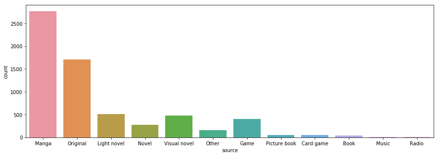

```python
plt.figure(figsize=(15,5))
source_bar = sns.countplot(x='source', data = animedf)
```

Then Below there is code to merge the picure bood and cardgame into a children target product lable, the music and radio into music, and the novel and book into novel.

```python
animedf['source'] = animedf['source'].replace(['Picture book', 'Card game'],'Children target product')
animedf['source'] = animedf['source'].replace(['Music', 'Radio'],'Music')
animedf['source'] = animedf['source'].replace(['Novel', 'Book'],'Novel')
```

Below ther is a graph of the sources after the change, and the categories with lowest values are still the same as the ones in the original graph, but simply palced together.

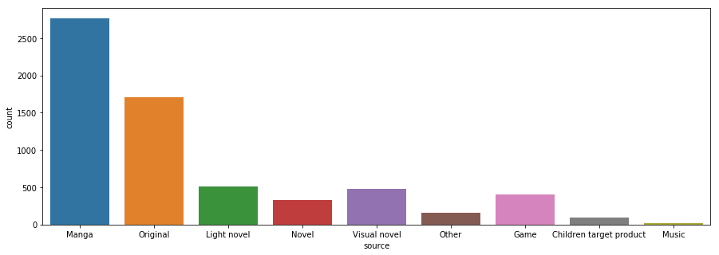

```python
plt.figure(figsize=(15,5))
source_bar = sns.countplot(x='source', data = animedf)
```

Bollow there is a graph for the status of the anime, and seeing that this data last update was 3 months ago. Then discarding the status column in the anime data is fine, as it might bear wrongfull information, as many of the currently airing anime have probably finished airing. So there is also code to remove this column.

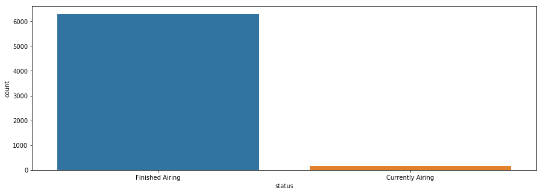

```python
plt.figure(figsize=(15,5))
status_bar = sns.countplot(x='status', data = animedf)
animedf.drop(['status'], axis = 1,inplace=True)
```

Below there is a graph of the differnt general scores per anime. doesn't say much other than a few have made it too the top. Looks pretty though.

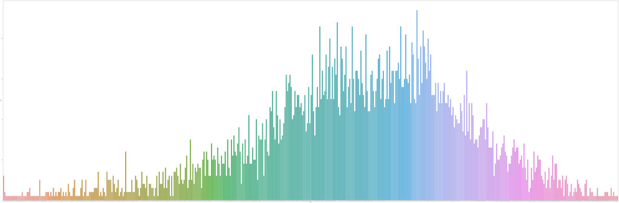

```python
plt.figure(figsize=(150,50))
score_bar = sns.countplot(x='score', data = animedf)
```

Looking at the data per anime in a whole graph reveals how deficult it is to analize some values look at the valus individually per anime. So it is time to look at these values some kind of aggregate. Sinse genre is the focuse of this tutorial, the below code is to make a new dataframe that contains the different genre as rows, and as columns the years that the anime table span. This is a nicer way to group the values per genre than some awkward group by a list of all the genre columns. I learned the method below to unpack from a calumn values that have the shape of a list of strings, in this kaggle [tutorial](https://www.kaggle.com/kevinmariogerard/tmdb-movie-dataset), by Kevin Mario Gerard, of an analysis on a movie dataset. This method is used throughout the tutorial. Furthermore the resulting dataframe helps view and understand the data better, at least the growth of each genre per year.

```python
#getting min and max year values, t define column values
min_year = animedf['aired_from_year'].min()
max_year = animedf['aired_from_year'].max()

#define data frame with range of years as column values and genres as rows
anime_genredf = pd.DataFrame(index = genres, columns = range(min_year, max_year+1))

#filling the data frame with zeros
anime_genredf = anime_genredf.fillna(value = 0)

#getting an array of the years of individual animes
year = np.array(animedf['aired_from_year'])
y = 0

#dictionary to collect number of different genres in total
genre_count = {}

#for loop to iterate through the list of genres per anime
for g in anime_genres_set:

    #split the anime's genre into a list
    split_genre = list(map(str, g.split(', ')))

    #iterate through the genres's of the anime
    for gs in split_genre:

        #add count for that genre in that year in the dataframe
        anime_genredf.loc[gs, year[y]] = anime_genredf.loc[gs, year[y]] + 1

        #count the dictionary
        if gs in genre_count:
            genre_count[gs] = genre_count[gs] + 1
        else:
             genre_count[gs] = 1
    y+=1
anime_genredf
```

|  | 1942 | 1943 | 1944 | 1945 | 1946 | 1947 | 1948 | 1949 | 1950 | 1951 | ... | 2009 | 2010 | 2011 | 2012 | 2013 | 2014 | 2015 | 2016 | 2017 | 2018 |
| --- | --- | --- | --- | --- | --- | --- | --- | --- | --- | --- | --- | --- | --- | --- | --- | --- | --- | --- | --- | --- | --- |
| Action | 0 | 0 | 0 | 1 | 0 | 0 | 0 | 0 | 0 | 0 | ... | 80 | 97 | 102 | 101 | 93 | 114 | 139 | 156 | 137 | 62 |
| Adventure | 0 | 1 | 0 | 0 | 0 | 0 | 0 | 0 | 0 | 0 | ... | 47 | 36 | 31 | 42 | 36 | 52 | 55 | 70 | 65 | 21 |
| Cars | 0 | 0 | 0 | 0 | 0 | 0 | 0 | 0 | 0 | 0 | ... | 3 | 0 | 0 | 3 | 0 | 2 | 2 | 2 | 0 | 1 |
| Comedy | 1 | 1 | 1 | 0 | 0 | 0 | 0 | 0 | 0 | 0 | ... | 137 | 148 | 136 | 153 | 161 | 200 | 231 | 238 | 191 | 79 |
| Dementia | 0 | 0 | 0 | 0 | 0 | 0 | 0 | 0 | 0 | 0 | ... | 0 | 0 | 2 | 0 | 2 | 3 | 0 | 3 | 3 | 2 |
| Demons | 0 | 0 | 0 | 0 | 0 | 0 | 0 | 0 | 0 | 0 | ... | 5 | 9 | 13 | 11 | 20 | 9 | 19 | 16 | 16 | 14 |
| Drama | 0 | 0 | 0 | 0 | 0 | 0 | 0 | 0 | 0 | 0 | ... | 41 | 34 | 47 | 46 | 46 | 49 | 57 | 75 | 81 | 34 |
| Ecchi | 0 | 0 | 0 | 0 | 0 | 0 | 0 | 0 | 0 | 0 | ... | 30 | 40 | 41 | 36 | 28 | 34 | 45 | 30 | 27 | 11 |
| Fantasy | 0 | 0 | 0 | 0 | 0 | 0 | 0 | 0 | 0 | 0 | ... | 58 | 48 | 54 | 61 | 78 | 94 | 100 | 116 | 133 | 44 |
| Game | 0 | 0 | 0 | 0 | 0 | 0 | 0 | 0 | 0 | 0 | ... | 5 | 4 | 9 | 9 | 12 | 23 | 7 | 28 | 23 | 5 |
| Harem | 0 | 0 | 0 | 0 | 0 | 0 | 0 | 0 | 0 | 0 | ... | 15 | 19 | 24 | 19 | 23 | 23 | 28 | 18 | 13 | 4 |
| Hentai | 0 | 0 | 0 | 0 | 0 | 0 | 0 | 0 | 0 | 0 | ... | 18 | 18 | 24 | 20 | 19 | 15 | 32 | 27 | 19 | 7 |
| Historical | 1 | 1 | 1 | 0 | 0 | 0 | 0 | 0 | 0 | 0 | ... | 16 | 28 | 22 | 16 | 13 | 22 | 18 | 33 | 35 | 10 |
| Horror | 0 | 0 | 0 | 0 | 0 | 0 | 0 | 0 | 0 | 0 | ... | 4 | 5 | 7 | 15 | 5 | 9 | 9 | 18 | 18 | 7 |
| Josei | 0 | 0 | 0 | 0 | 0 | 0 | 0 | 0 | 0 | 0 | ... | 2 | 6 | 6 | 7 | 8 | 6 | 1 | 6 | 3 | 2 |
| Kids | 0 | 0 | 0 | 0 | 0 | 0 | 0 | 0 | 0 | 0 | ... | 17 | 17 | 12 | 19 | 16 | 23 | 32 | 33 | 21 | 15 |
| Magic | 0 | 0 | 0 | 0 | 0 | 0 | 0 | 0 | 0 | 0 | ... | 23 | 23 | 27 | 22 | 27 | 32 | 33 | 49 | 67 | 15 |
| Martial Arts | 0 | 0 | 0 | 0 | 0 | 0 | 0 | 0 | 0 | 0 | ... | 9 | 10 | 12 | 7 | 6 | 11 | 5 | 7 | 6 | 4 |
| Mecha | 0 | 0 | 0 | 0 | 0 | 0 | 0 | 0 | 0 | 0 | ... | 14 | 15 | 9 | 15 | 17 | 30 | 25 | 23 | 20 | 11 |
| Military | 0 | 0 | 1 | 1 | 0 | 0 | 0 | 0 | 0 | 0 | ... | 12 | 18 | 10 | 13 | 8 | 9 | 19 | 16 | 19 | 6 |
| Music | 0 | 0 | 0 | 0 | 0 | 0 | 0 | 0 | 0 | 0 | ... | 9 | 9 | 8 | 11 | 16 | 21 | 31 | 33 | 31 | 7 |
| Mystery | 0 | 0 | 0 | 0 | 0 | 0 | 0 | 0 | 0 | 0 | ... | 21 | 18 | 24 | 23 | 19 | 25 | 32 | 35 | 34 | 11 |
| Parody | 0 | 0 | 0 | 0 | 0 | 0 | 0 | 0 | 0 | 0 | ... | 16 | 16 | 13 | 16 | 19 | 10 | 30 | 26 | 21 | 11 |
| Police | 0 | 0 | 0 | 0 | 0 | 0 | 0 | 0 | 0 | 0 | ... | 3 | 2 | 1 | 4 | 4 | 7 | 5 | 10 | 5 | 3 |
| Psychological | 0 | 0 | 0 | 0 | 0 | 0 | 0 | 0 | 0 | 0 | ... | 6 | 2 | 6 | 9 | 11 | 17 | 12 | 13 | 12 | 8 |
| Romance | 0 | 0 | 0 | 0 | 0 | 0 | 0 | 0 | 0 | 0 | ... | 52 | 42 | 53 | 66 | 61 | 70 | 61 | 66 | 71 | 27 |
| Samurai | 0 | 0 | 0 | 0 | 0 | 0 | 0 | 0 | 0 | 0 | ... | 4 | 13 | 8 | 6 | 6 | 4 | 5 | 8 | 5 | 2 |
| School | 0 | 0 | 0 | 0 | 0 | 0 | 0 | 0 | 0 | 0 | ... | 41 | 47 | 56 | 80 | 77 | 82 | 100 | 103 | 99 | 26 |
| Sci-Fi | 0 | 0 | 0 | 0 | 0 | 0 | 0 | 0 | 0 | 0 | ... | 33 | 37 | 34 | 52 | 34 | 60 | 54 | 68 | 64 | 26 |
| Seinen | 0 | 0 | 0 | 0 | 0 | 0 | 0 | 0 | 0 | 0 | ... | 15 | 30 | 24 | 35 | 28 | 40 | 46 | 41 | 28 | 18 |
| Shoujo | 0 | 0 | 0 | 0 | 0 | 0 | 0 | 0 | 0 | 0 | ... | 16 | 16 | 19 | 20 | 22 | 30 | 23 | 32 | 18 | 8 |
| Shoujo Ai | 0 | 0 | 0 | 0 | 0 | 0 | 0 | 0 | 0 | 0 | ... | 8 | 2 | 3 | 4 | 0 | 4 | 7 | 0 | 3 | 2 |
| Shounen | 0 | 0 | 0 | 0 | 0 | 0 | 0 | 0 | 0 | 0 | ... | 32 | 49 | 51 | 54 | 48 | 65 | 69 | 79 | 64 | 22 |
| Shounen Ai | 0 | 0 | 0 | 0 | 0 | 0 | 0 | 0 | 0 | 0 | ... | 0 | 2 | 4 | 2 | 1 | 6 | 1 | 7 | 2 | 2 |
| Slice of Life | 0 | 0 | 0 | 0 | 0 | 0 | 0 | 0 | 0 | 0 | ... | 29 | 28 | 41 | 54 | 71 | 91 | 90 | 87 | 94 | 39 |
| Space | 0 | 0 | 0 | 0 | 0 | 0 | 0 | 0 | 0 | 0 | ... | 5 | 3 | 4 | 4 | 7 | 15 | 9 | 15 | 9 | 3 |
| Sports | 0 | 0 | 0 | 0 | 0 | 0 | 0 | 0 | 0 | 0 | ... | 11 | 11 | 11 | 13 | 20 | 20 | 23 | 41 | 24 | 9 |
| Super Power | 0 | 0 | 0 | 0 | 0 | 0 | 0 | 0 | 0 | 0 | ... | 25 | 26 | 34 | 19 | 19 | 18 | 27 | 17 | 22 | 8 |
| Supernatural | 0 | 0 | 0 | 0 | 0 | 0 | 0 | 0 | 0 | 0 | ... | 30 | 47 | 65 | 52 | 50 | 56 | 70 | 82 | 64 | 30 |
| Thriller | 0 | 0 | 0 | 0 | 0 | 0 | 0 | 0 | 0 | 0 | ... | 10 | 5 | 5 | 6 | 5 | 5 | 4 | 4 | 2 | 4 |
| Vampire | 0 | 0 | 0 | 0 | 0 | 0 | 0 | 0 | 0 | 0 | ... | 2 | 5 | 10 | 3 | 6 | 0 | 12 | 7 | 8 | 2 |
| Yaoi | 0 | 0 | 0 | 0 | 0 | 0 | 0 | 0 | 0 | 0 | ... | 3 | 3 | 0 | 1 | 1 | 0 | 0 | 1 | 0 | 0 |
| Yuri | 0 | 0 | 0 | 0 | 0 | 0 | 0 | 0 | 0 | 0 | ... | 0 | 3 | 1 | 0 | 0 | 1 | 2 | 0 | 0 | 0 |

43 rows × 77 columns

To get a further feeling and understand of this newly found format lets make some graphs. First we are going to look at number of animes per genres. Below you'll find the code to get the data dictionary containg the the total number animes per genre, that was collected during the formaition of the new data frame, in a proper format for graphing, in this case a pandas series object. They are sorted to better understand the graphs, inparticular the pie chart that is also genereted by the rest of the code in the cell.

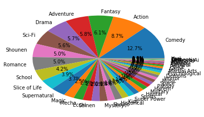

```python
#making series object conting the number of animes per series in the data
gens = pd.Series(genre_count)

#soerting the data
gens = gens.sort_values(ascending = False)

#plotting of pie chart per genre
label = list(map(str, gens.keys()))
label
fig1, ax1 = plt.subplots()
ax1.pie(gens, labels = label, autopct = '%1.1f%%')
plt.show()
```

From the pizza above clearly the comedy and action slices are the only descent ones. One might say that the most popular ones are similar to most of the genres in live action or animations from the "west". But then on the seventh position a Japaneese only genre appears, Shounen which basically means for young males. Those tend to be the most known anime, at least in the "west", for example Dragon Ball Z, Naruto or One Punch Man. Latter from the 12th position appears other Japanese genres such as: Mecha, robos; ecchi, sex appeal; seinen, young adult men; Shouju, teenage female. To further examin this data below there's bar graph of this same data.

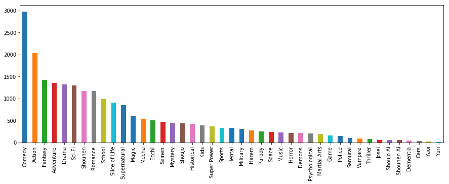

```python
plt.figure(figsize=(15,5))
gens.plot(kind='bar')
```

The bars above still show Comedy and action at the pop, prevalence of usual genres on top, then Japanese specific with low values. Which was also shown on the percentages in pie chart above. But this makes sence, a submedium that comes from the medium of story telling will have its basis on the general ones of the supramedium, and then develop its owns.

Now using the new format dataframe we print the change in poppulation size of different genres through the years. It looks cool, but its hard to really tell anything with such a small pallete of colors, and amount of values in the graph. So lets take a look at the same graph of the top and bot 5 genres in the data frame.

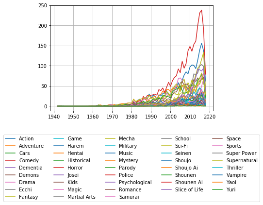

```python
plt.figure(figsize=(150,50))
anime_genredf.T.plot(grid = True)
plt.legend(loc=9, bbox_to_anchor=(0.5, -0.2), ncol=5)
```

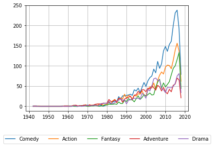

```python
#grab genres with top and bot 5 amount of anime from the dataset
gens_top10 = gens.nlargest(5)
gens_bot10 = gens.nsmallest(5)

#gram the subset of the dataframe by the top and low 5 genres
gen_top10df = anime_genredf.loc[gens_top10.keys()]
gen_bot10df = anime_genredf.loc[gens_bot10.keys()]

plt.figure(figsize=(150,50))
gen_top10df.T.plot(grid = True)
plt.legend(loc=9, bbox_to_anchor=(0.5, -0.2), ncol=5)
```

from here we see that these genres have grown a lot, from having very vew, probably, single digit values up to the 1980's. Then each picking up numbers, with comedy and action growing almost exponentially, while adventure and drama seem to show more of a linear growth, with some variation along the years. They all take a deep at the end, this is probably due to the low count of anime in 2018, as this data only covers only few tittles of that year.

Below you'll find the graph of the bottom 5 genres in the data set. Here we see that the genres had their first appearance at: cars, ~65; dementia, ~74; shounen ai, ~82; yaoi, ~93; yuri, maybe 04, hard to tell. All of them show a similar type of variation, where they may stay silent during periods of 5 to 10 years. With shounen ai grabbing the highest number, and highest population in the mid teens. Cars and Dementia vary in a more similar fashon, between the zeros and 3 animes per year.

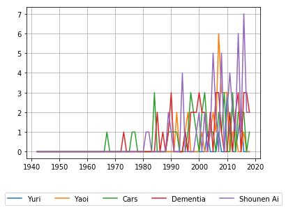

```python
plt.figure(figsize=(150,50))
gen_bot10df.T.plot(grid = True)
plt.legend(loc=9, bbox_to_anchor=(0.5, -0.2), ncol=5)
```

So far this exploration of genre in each year has been interesting. However these are the mere frequency of the genres throught the years, what about the other variables. In the next section we will explore more, with the newly found format of genre per year, but reflecting other atributes other than frequency. In the cell below we got the code to generate three different dataframes with the same rows, genres and columns, years, but with the values of popularity, score and membership, each in a different data frame.

```python
genres_pop=[]
genres_score=[]
genres_mem=[]

#collecting special lables for each new data frame
for g in genres:
    g_pop = g + ' popularity'
    g_score = g + ' score'
    g_mem = g + ' members'
    genres_pop.append(g_pop)
    genres_score.append(g_score)
    genres_mem.append(g_mem)

anime_popdf = pd.DataFrame(index = genres_pop, columns = range(min_year, max_year+1))
anime_popdf = anime_popdf.fillna(value = 0.0)
anime_pop = np.array(animedf['popularity'])
pop_count = {}

anime_scoredf = pd.DataFrame(index = genres_score, columns = range(min_year, max_year+1))
anime_scoredf = anime_scoredf.fillna(value = 0.0)
anime_score = np.array(animedf['score'])
score_count = {}

anime_memdf = pd.DataFrame(index = genres_mem, columns = range(min_year, max_year+1))
anime_memdf = anime_memdf.fillna(value = 0.0)
anime_mem = np.array(animedf['members'])
mem_count = {}

y=0
for g in anime_genres_set:
    split_genre = list(map(str, g.split(', ')))
    for gs in split_genre:
        anime_popdf.loc[gs+' popularity', year[y]] = anime_popdf.loc[gs+' popularity', year[y]] + anime_pop[y]
        anime_scoredf.loc[gs+ ' score', year[y]] = anime_scoredf.loc[gs+ ' score', year[y]] + anime_score[y]
        anime_memdf.loc[gs+ ' members', year[y]] = anime_memdf.loc[gs+ ' members', year[y]] + anime_mem[y]
        if gs+' popularity' in pop_count:
            pop_count[gs+' popularity'] = pop_count[gs+' popularity'] + anime_pop[y]
            score_count[gs+' score'] = score_count[gs+' score'] + anime_score[y]
            mem_count[gs+' members'] = mem_count[gs+' members'] + anime_mem[y]
        else:
            pop_count[gs+' popularity'] = anime_pop[y]
            score_count[gs+' score'] = anime_score[y]
            mem_count[gs+' members'] = anime_mem[y]
    y+=1

#standardizing the score and popularity data frames as those values refelct a quality metric rather than a quantitative one
anime_popdf2 = (anime_popdf - anime_popdf.mean()) / anime_popdf.std(ddof = 0)
anime_scoredf2 = (anime_scoredf - anime_scoredf.mean()) / anime_scoredf.std(ddof = 0)

#averaging the count of the scores of the popularity and score by the tottal number of animes in each genre in the data set
for g in genres:
    score_count[g+' score'] = score_count[g+' score']/genre_count[g]
```

Next to examine these 3 variables in these genre per year format, we will treat them as we did with the first genre per year format. So we will see bar graphs of each variable per genre and line plots of each variable per genre over the years.

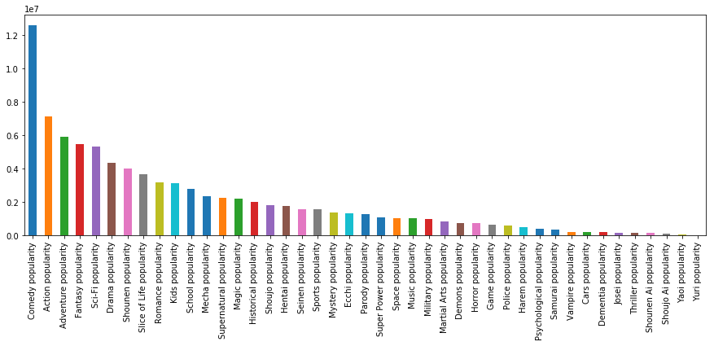

```python
pops = pd.Series(pop_count)
pops = pops.sort_values(ascending = False)
plt.figure(figsize=(15,5))
pops.plot(kind='bar')
```

The bar graph above shows the popularity of each genre in the site. So the amount of visits to animes of that genre.

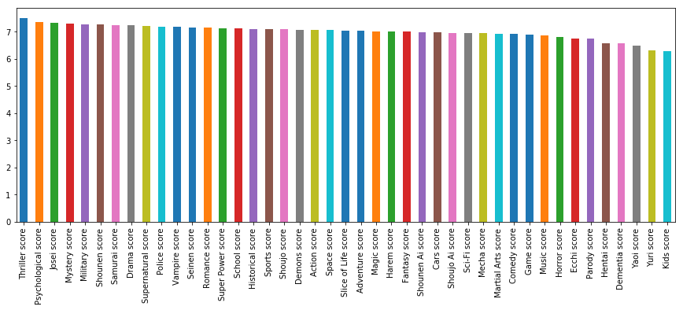

```python
scores = pd.Series(score_count)
scores = scores.sort_values(ascending = False)
plt.figure(figsize=(15,5))
scores.plot(kind='bar')
```

Above there's a bar graph with the sum of scores per genres divide by the numer of animes of that genre.

[figure not shown]

```python
mems = pd.Series(mem_count)
mems = mems.sort_values(ascending = False)
plt.figure(figsize=(15,5))
mems.plot(kind='bar')
```

The bar graph above shows the user membership number of animes by genre.

Bellow there're three line plots, each showing the change of the three values being inspected by genre per year.

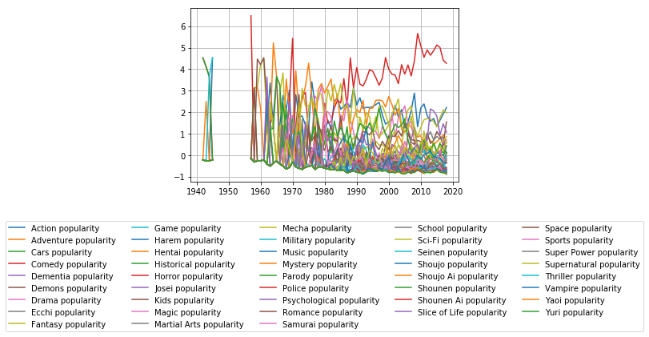

```python
plt.figure(figsize=(15,8))
anime_popdf2.T.plot(grid = True)
plt.legend(loc=9, bbox_to_anchor=(0.5, -0.2), ncol=5)
```

The graph above shows the change of a genre's popularity through time.

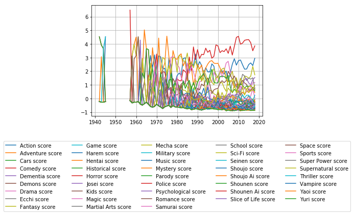

```python
plt.figure(figsize=(15,5))
anime_scoredf2.T.plot(grid = True)
plt.legend(loc=9, bbox_to_anchor=(0.5, -0.2), ncol=5)
```

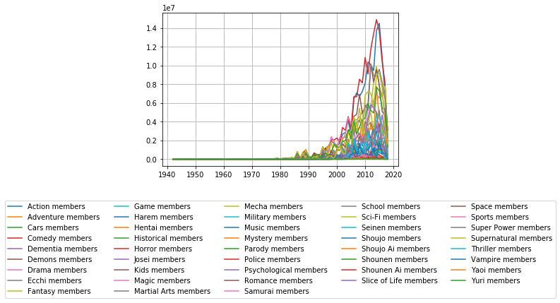

```python
plt.figure(figsize=(150,50))
anime_memdf.T.plot(grid = True)
plt.legend(loc=9, bbox_to_anchor=(0.5, -0.2), ncol=5)
```

Above you'll find a graph of the change of number of MAL users are members of animes of a genre per year of release.

These line plots bear the same palet and cuantity of lines as the genres per year graph. So to better explore this data a print of six more line graphs will be provided: 2 per atribute, for each, one will contain the top 5 values in that atribute and the other bottm the 5 bottom values in that atribute. Bellow you will find the code to print these 6 particular graphs and the graphs. Free to look at.

```python
pops_top10 = pops.nlargest(5)
pops_bot10 = pops.nsmallest(5)
scores_top10 = scores.nlargest(5)
scores_bot10 = scores.nsmallest(5)
mems_top10 = mems.nlargest(5)
mems_bot10 = mems.nsmallest(5)

pop_top10df = anime_popdf.loc[pops_top10.keys()]
pop_bot10df = anime_popdf.loc[pops_bot10.keys()]
score_top10df = anime_scoredf2.loc[scores_top10.keys()]
score_bot10df = anime_scoredf2.loc[scores_bot10.keys()]
mem_top10df = anime_memdf.loc[mems_top10.keys()]
mem_bot10df = anime_memdf.loc[mems_bot10.keys()]
```

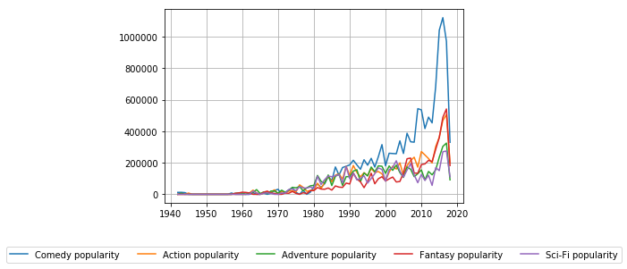

```python
plt.figure(figsize=(150,50))
pop_top10df.T.plot(grid = True)
plt.legend(loc=9, bbox_to_anchor=(0.5, -0.2), ncol=5)
```

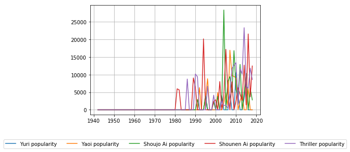

```python
plt.figure(figsize=(150,50))
pop_bot10df.T.plot(grid = True)
plt.legend(loc=9, bbox_to_anchor=(0.5, -0.2), ncol=5)
```

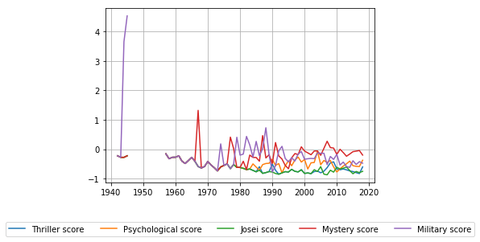

```python
plt.figure(figsize=(150,50))
score_top10df.T.plot(grid = True)
plt.legend(loc=9, bbox_to_anchor=(0.5, -0.2), ncol=5)
```

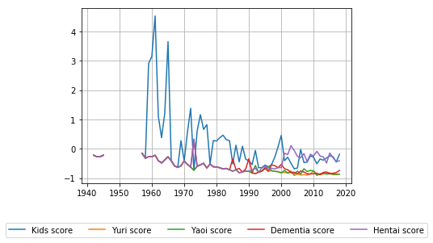

```python
plt.figure(figsize=(150,50))
score_bot10df.T.plot(grid = True)
plt.legend(loc=9, bbox_to_anchor=(0.5, -0.2), ncol=5)
```

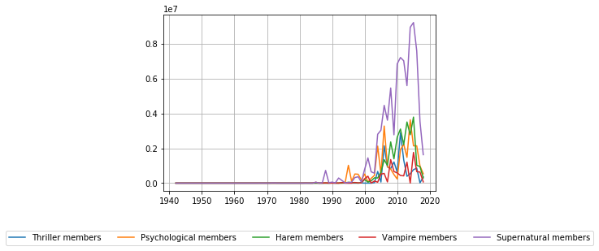

```python
plt.figure(figsize=(150,50))
mem_top10df.T.plot(grid = True)
plt.legend(loc=9, bbox_to_anchor=(0.5, -0.2), ncol=5)
```

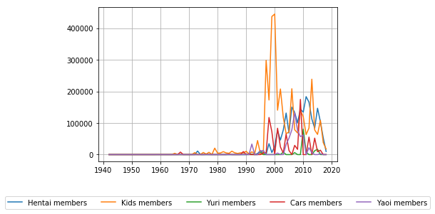

```python
plt.figure(figsize=(150,50))
mem_bot10df.T.plot(grid = True)
plt.legend(loc=9, bbox_to_anchor=(0.5, -0.2), ncol=5)
```

To end this data exploration section, here I print a datframe of the count of different combinations of genres throught the year. The method to collect this data frame is the same as with the 4 previos ones. No graph will be provided, as sometimes a table is enough, to explore data. Also because that is another rabbit whole I shant enter right now.

```python
genre_mix_count = {}
for g in anime_genres_set:
    split_genre = list(map(str, g.split(', ')))
    split_genre.sort()
    g_str = ' '.join(split_genre)
    if g_str in genre_mix_count:
        genre_mix_count[g_str] = genre_mix_count[g_str] + 1
    else:
        genre_mix_count[g_str] = 1
genre_mix_set = list(map(str, genre_mix_count.keys()))
anime_mix_genredf = pd.DataFrame(index = genre_mix_set, columns = range(min_year, max_year+1))
anime_mix_genredf = anime_mix_genredf.fillna(value = 0)
y=0
for g in anime_genres_set:
    split_genre = list(map(str, g.split(', ')))
    split_genre.sort()
    g_str = ' '.join(split_genre)
    anime_mix_genredf.loc[g_str, year[y]] = anime_mix_genredf.loc[g_str, year[y]] + 1
    y+=1
anime_mix_genredf.sort_index()
```

|  | 1942 | 1943 | 1944 | 1945 | 1946 | 1947 | 1948 | 1949 | 1950 | 1951 | ... | 2009 | 2010 | 2011 | 2012 | 2013 | 2014 | 2015 | 2016 | 2017 | 2018 |
| --- | --- | --- | --- | --- | --- | --- | --- | --- | --- | --- | --- | --- | --- | --- | --- | --- | --- | --- | --- | --- | --- |
| Action | 0 | 0 | 0 | 0 | 0 | 0 | 0 | 0 | 0 | 0 | ... | 1 | 0 | 1 | 0 | 0 | 0 | 1 | 2 | 3 | 1 |
| Action Adventure | 0 | 0 | 0 | 0 | 0 | 0 | 0 | 0 | 0 | 0 | ... | 0 | 0 | 0 | 0 | 0 | 0 | 0 | 0 | 0 | 0 |
| Action Adventure Cars Comedy Kids Police | 0 | 0 | 0 | 0 | 0 | 0 | 0 | 0 | 0 | 0 | ... | 0 | 0 | 0 | 0 | 0 | 0 | 0 | 0 | 0 | 0 |
| Action Adventure Cars Comedy Sci-Fi Shounen | 0 | 0 | 0 | 0 | 0 | 0 | 0 | 0 | 0 | 0 | ... | 0 | 0 | 0 | 0 | 0 | 0 | 0 | 0 | 0 | 0 |
| Action Adventure Cars Mecha Sci-Fi Shounen Sports | 0 | 0 | 0 | 0 | 0 | 0 | 0 | 0 | 0 | 0 | ... | 0 | 0 | 0 | 0 | 0 | 0 | 0 | 0 | 0 | 0 |
| Action Adventure Cars Sci-Fi | 0 | 0 | 0 | 0 | 0 | 0 | 0 | 0 | 0 | 0 | ... | 1 | 0 | 0 | 0 | 0 | 0 | 0 | 0 | 0 | 0 |
| Action Adventure Comedy | 0 | 0 | 0 | 0 | 0 | 0 | 0 | 0 | 0 | 0 | ... | 0 | 0 | 0 | 0 | 0 | 0 | 0 | 0 | 0 | 0 |
| Action Adventure Comedy Demons Drama Ecchi Horror Mystery Romance Sci-Fi | 0 | 0 | 0 | 0 | 0 | 0 | 0 | 0 | 0 | 0 | ... | 0 | 0 | 0 | 0 | 0 | 0 | 0 | 0 | 0 | 0 |
| Action Adventure Comedy Demons Fantasy Historical Magic Romance Shounen Supernatural | 0 | 0 | 0 | 0 | 0 | 0 | 0 | 0 | 0 | 0 | ... | 1 | 0 | 0 | 0 | 0 | 0 | 0 | 0 | 0 | 0 |
| Action Adventure Comedy Demons Fantasy Magic | 0 | 0 | 0 | 0 | 0 | 0 | 0 | 0 | 0 | 0 | ... | 0 | 0 | 0 | 0 | 0 | 0 | 0 | 0 | 0 | 0 |
| Action Adventure Comedy Demons Fantasy Martial Arts Shounen Super Power | 0 | 0 | 0 | 0 | 0 | 0 | 0 | 0 | 0 | 0 | ... | 0 | 0 | 0 | 0 | 0 | 0 | 0 | 0 | 0 | 0 |
| Action Adventure Comedy Demons Shounen Super Power | 0 | 0 | 0 | 0 | 0 | 0 | 0 | 0 | 0 | 0 | ... | 0 | 0 | 0 | 0 | 0 | 0 | 0 | 0 | 0 | 0 |
| Action Adventure Comedy Demons Shounen Supernatural | 0 | 0 | 0 | 0 | 0 | 0 | 0 | 0 | 0 | 0 | ... | 0 | 0 | 0 | 0 | 0 | 0 | 1 | 1 | 0 | 0 |
| Action Adventure Comedy Drama | 0 | 0 | 0 | 0 | 0 | 0 | 0 | 0 | 0 | 0 | ... | 0 | 0 | 0 | 0 | 0 | 0 | 2 | 2 | 2 | 1 |
| Action Adventure Comedy Drama Ecchi Mecha Romance Sci-Fi | 0 | 0 | 0 | 0 | 0 | 0 | 0 | 0 | 0 | 0 | ... | 0 | 0 | 0 | 0 | 0 | 0 | 0 | 0 | 0 | 0 |
| Action Adventure Comedy Drama Fantasy Historical | 0 | 0 | 0 | 0 | 0 | 0 | 0 | 0 | 0 | 0 | ... | 0 | 0 | 0 | 0 | 0 | 0 | 0 | 0 | 0 | 0 |
| Action Adventure Comedy Drama Fantasy Josei | 0 | 0 | 0 | 0 | 0 | 0 | 0 | 0 | 0 | 0 | ... | 0 | 0 | 0 | 0 | 0 | 0 | 0 | 0 | 0 | 0 |
| Action Adventure Comedy Drama Fantasy Kids | 0 | 0 | 0 | 0 | 0 | 0 | 0 | 0 | 0 | 0 | ... | 1 | 0 | 0 | 1 | 0 | 0 | 0 | 0 | 0 | 0 |
| Action Adventure Comedy Drama Fantasy Magic Military Shounen | 0 | 0 | 0 | 0 | 0 | 0 | 0 | 0 | 0 | 0 | ... | 1 | 0 | 1 | 0 | 0 | 0 | 0 | 0 | 0 | 0 |
| Action Adventure Comedy Drama Fantasy Shounen | 0 | 0 | 0 | 0 | 0 | 0 | 0 | 0 | 0 | 0 | ... | 1 | 0 | 0 | 1 | 0 | 0 | 0 | 2 | 0 | 0 |
| Action Adventure Comedy Drama Fantasy Shounen Super Power | 0 | 0 | 0 | 0 | 0 | 0 | 0 | 0 | 0 | 0 | ... | 0 | 0 | 0 | 1 | 1 | 0 | 2 | 0 | 1 | 0 |
| Action Adventure Comedy Drama Harem Martial Arts Mecha Romance Sci-Fi Shounen | 0 | 0 | 0 | 0 | 0 | 0 | 0 | 0 | 0 | 0 | ... | 0 | 0 | 0 | 0 | 0 | 0 | 0 | 0 | 0 | 0 |
| Action Adventure Comedy Drama Historical Military Romance | 0 | 0 | 0 | 0 | 0 | 0 | 0 | 0 | 0 | 0 | ... | 0 | 0 | 0 | 0 | 0 | 0 | 0 | 0 | 0 | 0 |
| Action Adventure Comedy Drama Horror Mecha Mystery Psychological Sci-Fi | 0 | 0 | 0 | 0 | 0 | 0 | 0 | 0 | 0 | 0 | ... | 0 | 0 | 0 | 0 | 0 | 0 | 0 | 0 | 0 | 0 |
| Action Adventure Comedy Drama Josei Supernatural | 0 | 0 | 0 | 0 | 0 | 0 | 0 | 0 | 0 | 0 | ... | 0 | 0 | 0 | 0 | 0 | 0 | 0 | 0 | 1 | 0 |
| Action Adventure Comedy Drama Mecha Military Music Romance Sci-Fi Shounen | 0 | 0 | 0 | 0 | 0 | 0 | 0 | 0 | 0 | 0 | ... | 0 | 0 | 0 | 0 | 0 | 0 | 0 | 0 | 0 | 0 |
| Action Adventure Comedy Drama Mecha Music Sci-Fi Shounen | 0 | 0 | 0 | 0 | 0 | 0 | 0 | 0 | 0 | 0 | ... | 0 | 0 | 0 | 0 | 0 | 0 | 0 | 0 | 0 | 0 |
| Action Adventure Comedy Drama Mecha Sci-Fi Shounen | 0 | 0 | 0 | 0 | 0 | 0 | 0 | 0 | 0 | 0 | ... | 0 | 0 | 0 | 0 | 0 | 0 | 0 | 0 | 0 | 0 |
| Action Adventure Comedy Drama Romance Sci-Fi | 0 | 0 | 0 | 0 | 0 | 0 | 0 | 0 | 0 | 0 | ... | 0 | 0 | 0 | 0 | 0 | 0 | 0 | 0 | 0 | 0 |
| Action Adventure Comedy Drama School Sci-Fi Shounen Sports | 0 | 0 | 0 | 0 | 0 | 0 | 0 | 0 | 0 | 0 | ... | 0 | 0 | 0 | 0 | 0 | 0 | 0 | 0 | 0 | 0 |
| ... | ... | ... | ... | ... | ... | ... | ... | ... | ... | ... | ... | ... | ... | ... | ... | ... | ... | ... | ... | ... | ... |
| School Sports | 0 | 0 | 0 | 0 | 0 | 0 | 0 | 0 | 0 | 0 | ... | 0 | 0 | 0 | 0 | 0 | 0 | 0 | 1 | 0 | 0 |
| School Supernatural | 0 | 0 | 0 | 0 | 0 | 0 | 0 | 0 | 0 | 0 | ... | 0 | 1 | 0 | 0 | 0 | 0 | 0 | 0 | 0 | 0 |
| Sci-Fi | 0 | 0 | 0 | 0 | 0 | 0 | 0 | 0 | 0 | 0 | ... | 0 | 1 | 0 | 2 | 0 | 0 | 0 | 3 | 7 | 0 |
| Sci-Fi Seinen | 0 | 0 | 0 | 0 | 0 | 0 | 0 | 0 | 0 | 0 | ... | 0 | 0 | 0 | 0 | 1 | 0 | 0 | 2 | 0 | 0 |
| Sci-Fi Seinen Slice of Life | 0 | 0 | 0 | 0 | 0 | 0 | 0 | 0 | 0 | 0 | ... | 0 | 0 | 0 | 0 | 0 | 0 | 0 | 0 | 0 | 0 |
| Sci-Fi Seinen Space | 0 | 0 | 0 | 0 | 0 | 0 | 0 | 0 | 0 | 0 | ... | 0 | 0 | 0 | 0 | 0 | 0 | 0 | 0 | 0 | 0 |
| Sci-Fi Shounen | 0 | 0 | 0 | 0 | 0 | 0 | 0 | 0 | 0 | 0 | ... | 1 | 0 | 0 | 0 | 0 | 0 | 0 | 0 | 0 | 0 |
| Sci-Fi Shounen Sports Super Power | 0 | 0 | 0 | 0 | 0 | 0 | 0 | 0 | 0 | 0 | ... | 0 | 0 | 1 | 0 | 0 | 0 | 0 | 0 | 0 | 0 |
| Sci-Fi Slice of Life | 0 | 0 | 0 | 0 | 0 | 0 | 0 | 0 | 0 | 0 | ... | 0 | 1 | 0 | 0 | 0 | 0 | 0 | 0 | 0 | 0 |
| Sci-Fi Space | 0 | 0 | 0 | 0 | 0 | 0 | 0 | 0 | 0 | 0 | ... | 0 | 0 | 0 | 1 | 0 | 1 | 1 | 0 | 0 | 0 |
| Sci-Fi Sports | 0 | 0 | 0 | 0 | 0 | 0 | 0 | 0 | 0 | 0 | ... | 0 | 0 | 0 | 0 | 0 | 0 | 0 | 0 | 0 | 0 |
| Sci-Fi Thriller | 0 | 0 | 0 | 0 | 0 | 0 | 0 | 0 | 0 | 0 | ... | 0 | 0 | 1 | 0 | 0 | 0 | 1 | 0 | 1 | 1 |
| Seinen | 0 | 0 | 0 | 0 | 0 | 0 | 0 | 0 | 0 | 0 | ... | 0 | 0 | 0 | 0 | 0 | 0 | 0 | 0 | 0 | 0 |
| Seinen Slice of Life | 0 | 0 | 0 | 0 | 0 | 0 | 0 | 0 | 0 | 0 | ... | 0 | 0 | 0 | 1 | 0 | 0 | 2 | 0 | 1 | 2 |
| Seinen Slice of Life Supernatural | 0 | 0 | 0 | 0 | 0 | 0 | 0 | 0 | 0 | 0 | ... | 0 | 0 | 0 | 0 | 1 | 0 | 0 | 0 | 0 | 0 |
| Seinen Sports | 0 | 0 | 0 | 0 | 0 | 0 | 0 | 0 | 0 | 0 | ... | 0 | 0 | 0 | 0 | 0 | 1 | 0 | 0 | 0 | 0 |
| Shoujo | 0 | 0 | 0 | 0 | 0 | 0 | 0 | 0 | 0 | 0 | ... | 0 | 0 | 0 | 0 | 0 | 0 | 0 | 0 | 0 | 0 |
| Shoujo Slice of Life | 0 | 0 | 0 | 0 | 0 | 0 | 0 | 0 | 0 | 0 | ... | 0 | 1 | 0 | 0 | 1 | 0 | 0 | 0 | 0 | 0 |
| Shounen | 0 | 0 | 0 | 0 | 0 | 0 | 0 | 0 | 0 | 0 | ... | 0 | 0 | 0 | 0 | 0 | 0 | 0 | 0 | 0 | 0 |
| Shounen Sports | 0 | 0 | 0 | 0 | 0 | 0 | 0 | 0 | 0 | 0 | ... | 0 | 0 | 0 | 1 | 0 | 1 | 1 | 1 | 0 | 0 |
| Shounen Sports Super Power | 0 | 0 | 0 | 0 | 0 | 0 | 0 | 0 | 0 | 0 | ... | 0 | 0 | 1 | 1 | 1 | 0 | 0 | 0 | 0 | 0 |
| Shounen Super Power | 0 | 0 | 0 | 0 | 0 | 0 | 0 | 0 | 0 | 0 | ... | 0 | 0 | 0 | 0 | 0 | 0 | 0 | 1 | 0 | 0 |
| Shounen Supernatural | 0 | 0 | 0 | 0 | 0 | 0 | 0 | 0 | 0 | 0 | ... | 0 | 0 | 0 | 0 | 0 | 0 | 0 | 0 | 1 | 0 |
| Slice of Life | 0 | 0 | 0 | 0 | 0 | 0 | 0 | 0 | 0 | 0 | ... | 0 | 0 | 1 | 2 | 3 | 6 | 5 | 6 | 9 | 1 |
| Slice of Life Space | 0 | 0 | 0 | 0 | 0 | 0 | 0 | 0 | 0 | 0 | ... | 0 | 0 | 0 | 0 | 1 | 0 | 0 | 0 | 0 | 0 |
| Slice of Life Supernatural | 0 | 0 | 0 | 0 | 0 | 0 | 0 | 0 | 0 | 0 | ... | 0 | 0 | 0 | 0 | 0 | 1 | 1 | 0 | 0 | 1 |
| Space | 0 | 0 | 0 | 0 | 0 | 0 | 0 | 0 | 0 | 0 | ... | 0 | 0 | 0 | 1 | 0 | 0 | 0 | 0 | 0 | 0 |
| Sports | 0 | 0 | 0 | 0 | 0 | 0 | 0 | 0 | 0 | 0 | ... | 0 | 0 | 1 | 0 | 1 | 0 | 0 | 4 | 2 | 3 |
| Supernatural | 0 | 0 | 0 | 0 | 0 | 0 | 0 | 0 | 0 | 0 | ... | 0 | 0 | 0 | 0 | 0 | 0 | 0 | 1 | 0 | 0 |
| Yaoi | 0 | 0 | 0 | 0 | 0 | 0 | 0 | 0 | 0 | 0 | ... | 0 | 0 | 0 | 0 | 0 | 0 | 0 | 0 | 0 | 0 |

2623 rows × 77 columns

Not the whole table above is visible here, well the table found 2600 differnt combinations in this data set. however the trend of having more cells filled at the latter years than the first ones is still interesting. Howevevr this is far more sparce than the genres not combined, as this frame counts the animes strictly by their genres combinations.

[figure not shown]

## Data folding

```python
#Make a pandas series object containing the sum of animes per year from the anime data frame
#this will be used as the target values for the model
year = np.array(animedf['aired_from_year'])
years = range(min_year, max_year+1)
year_count = {}
for y in years:
    year_count[str(y)] = 0
for y in year:
    if str(y) in year_count:
        year_count[str(y)] = year_count[str(y)] + 1
year_counts = pd.Series(year_count)

#Make a user pandas series object containing the the user names and number
#of animes rated by those users from the user anime list data frame
#this was used to look at the numbers in the different lists
#from there I saw some user and decided to uses him as my guinea pig.
user_set = list(map(str, (anime_listsdf['username'])))
user_count = {}
for u in user_set:
    if u in user_count:
        user_count[u] = user_count[u] + 1
    else:
        user_count[u] = 1
users = pd.Series(user_count)
users = users.sort_values(ascending = False)

#Get the table of the animes from the user's list to a data frame
anime_id_set = list(map(str, (animedf['anime_id'])))
fire_dragon_animesdf = anime_listsdf[anime_listsdf['username'] == 'Fire-Dragon']
fire_dragon_animesdf.reset_index(drop=True)
fire_dragon_anime_id_set = list(map(str, (fire_dragon_animesdf['anime_id'])))
fire_dragon_animesdf2 = pd.DataFrame(columns = list(animedf.columns.values))
for a in fire_dragon_anime_id_set:
    fire_dragon_animesdf2 = fire_dragon_animesdf2.append(animedf[animedf['anime_id'] == int(a)])
fire_dragon_genres_set = list(map(str, (fire_dragon_animesdf2['genre'])))

fire_dragon_year = np.array(fire_dragon_animesdf2['aired_from_year'])
fire_dragon_years = range(min_year, max_year+1)
fire_dragon_year_count = {}
for y in years:
    fire_dragon_year_count[str(y)] = 0
for y in fire_dragon_year:
    if str(y) in fire_dragon_year_count:
        fire_dragon_year_count[str(y)] = fire_dragon_year_count[str(y)] + 1
fire_dragon_year_counts = pd.Series(fire_dragon_year_count)

#get the users anime list data frame of the format of genre per year
fire_dragon_genredf = pd.DataFrame(index = genres, columns = range(min_year, max_year+1))
fire_dragon_genredf = fire_dragon_genredf.fillna(value = 0)
y = 0
fire_dragon_genre_count = {}
for g in fire_dragon_genres_set:
    split_genre = list(map(str, g.split(', ')))
    for gs in split_genre:
        fire_dragon_genredf.loc[gs, year[y]] = fire_dragon_genredf.loc[gs, year[y]] + 1
        if gs in fire_dragon_genre_count:
            fire_dragon_genre_count[gs] = fire_dragon_genre_count[gs] + 1
        else:
            fire_dragon_genre_count[gs] = 1
    y+=1
```

Bellow you'll find the code that makes the model. The model uses the the transpose of the anime genres by year frequency data drame as the X input, so the genres are the columns/atributes are the genres, and the rows/entries are the years. The target values are total anime by year. This model uses by default the gini index criteria, which basically takes the most probable value to atribute that will decide the calissification of the object, in this case the differnt genres. This model uses 10 estimators by default, that is to say it generates 10 trees to average out Then there is some code to print relrevance of each anime to determine an animes genres.

```python
#fitting random forest classifier model
#X variebles anime genre by year data frame
#Y amount of animes per year
clf = RandomForestClassifier()
clf = clf.fit(anime_genredf.T.sort_index(),year_counts.sort_index())

#for loop to print the importance of each genre in the model
i = 0
for f in clf.feature_importances_:
    print(genres[i], f)
    i+=1
```

```
Action 0.05118839111668779
Adventure 0.10157282990913039
Cars 0.003920848038099575
Comedy 0.08690454098593776
Dementia 0.012056233439961858
Demons 0.022299341469234884
Drama 0.04134026437305148
Ecchi 0.008495769850454655
Fantasy 0.045046285468479504
Game 0.007282303723872537
Harem 0.003904139697664956
Hentai 0.00889580999519934
Historical 0.04437481246172088
Horror 0.02056034654841172
Josei 0.007757591430792102
Kids 0.04257155167082658
Magic 0.015094419184070043
Martial Arts 0.01335564949749311
Mecha 0.04874923404032387
Military 0.027625089649590345
Music 0.014198246978283738
Mystery 0.007782758268890372
Parody 0.006159060053567499
Police 0.0181292304146359
Psychological 0.021463514504780304
Romance 0.019607624519015324
Samurai 0.0066314294892255545
School 0.02162411009641448
Sci-Fi 0.04317080822365747
Seinen 0.01248832927941593
Shoujo 0.009853189279050687
Shoujo Ai 0.0013686455741201563
Shounen 0.04929837788581652
Shounen Ai 0.005874926007505961
Slice of Life 0.02399497399686796
Space 0.02417442904142212
Sports 0.026074964188795718
Super Power 0.020219853482099443
Supernatural 0.017821020781230067
Thriller 0.004857191890186035
Vampire 0.009958962011908972
Yaoi 0.010272971320591382
Yuri 0.011979930161514973
```

Below there is code to prinr the model the decision tree generated. Since the rows of the model where the years, the tree might be interepreted as the likelly hood an anime is from some year based on this genre, or vise-sersa. Where the leaves that have no genre attribute to them simply specify the possible years of the genres path of a certain anime.

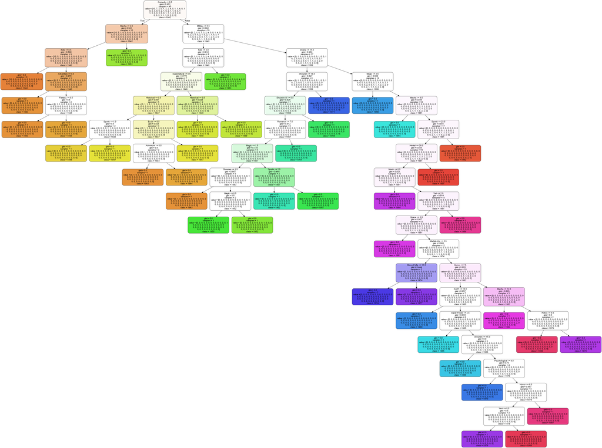

```python
estimator = clf.estimators_[5]

dot_data = export_graphviz(estimator, out_file=None,
                feature_names = genres,
                class_names = list(year_count.keys()),
                rounded = True, filled = True)
graph =  pydot.graph_from_dot_data(dot_data)
Image(graph[0].create_png())
```

The cell bellow contains a prediction of the model based on a users anime list. And it contains a list reflecting the years in which the users anime list got predicted, besed on genre.

```python
#prediction based on a MAL user anime list
predicted_genres = clf.predict(fire_dragon_genredf.T)

#Code to print the predictions results
liist_years = list(year_count.keys())
i = 0
for f in predicted_genres:
    print(liist_years[i], f)
    i+=1
```

```
1942 0
1943 1
1944 2
1945 0
1946 0
1947 0
1948 0
1949 0
1950 0
1951 0
1952 0
1953 0
1954 0
1955 0
1956 0
```

[output cut: 62 more lines]

[figure not shown]

## Data wearing

To wrapp up this tutorial let me say that eventhough the tutorial was attempeted to be divide by data cleaning, exploration and analisis sections, the tutorial throughout showed compenets of previous sections. This reflects how the process of analysing data, has no linear progress, but oftes requires stepping back to previous stages of analisys. This is not seen in the last stage of this tutorial, that is because there is more to explore in the model, as there is more to explore in any other stage. During each stage there were several lines of questioning about the data left un-answered in general to clean, analyse, understand and/or run models on. The data could be set up to add the variables as more atributes for the model, such as genre per score, or genre per popularity. Or maybe even look for more atributes whose exploration might suggest better candidacy to include in the model... All this is to say that this tutorial if anything has also inspired me to understand ways of exploring data and be able to apply the learned value of data.

Furthemore I shared some fun facts about anime through out the tutorial, for those curious about the subject here are a couple of [anime](https://www.youtube.com/channel/UC_X2BzWhnbpLN0hkeMtxXUw) youtube [channels](https://www.youtube.com/channel/UCBs2Y3i14e1NWQxOGliatmg/featured) that cover several topics explored here. But may mane recomendation is to simply watch some anime.